title: “Statistical Models Homework 1” author: “Sourabh Prakash and Priyanshi Shah” date: “2023-01-20” output: pdf_document: default —

```r
#To set path to the working directory, please paste your path below where 04cars.rda dataset is located and uncomment the code below

#setwd("D:/projects/R_Projects/Sandbox/Stats_model_assignments")
#getwd()
```

### Question 1

Write a function confBand(x, y, conf=0.95) taking in a predictor vector (x1, . . . , xn) and a response vector y = (y1,…,yn) and return a plot with the points (x1,y1),…,(xn,yn), the least squares line, and the confidence band at level conf. Apply your function to hp and mpg from the 04cars dataset.

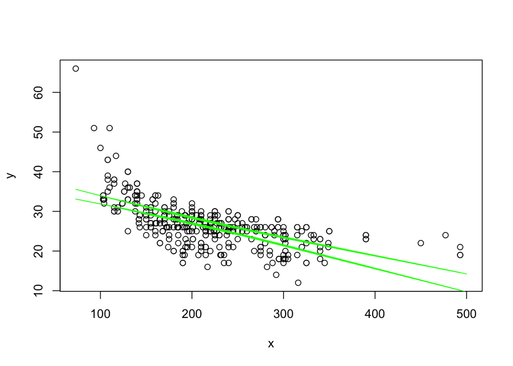

```r
#Loading the cars dataset
load("04cars.rda")
data = dat[,c(13,15)]
names(data) = c("hp", "mpg")

#defining the confBand function
confBand <- function(x,y, conf = 0.95){

  n = 100
  #Plotting the linear model
  linear_model = lm(y~x)
  p=1
  df_1 = p+1 #degree of freedom 1
  df_2=n-p-1  #degree of freedom 2
  fquartile = sqrt((p+1) * qf(conf, df_1,df_2))

  #Calculating y bar
  y_ = predict(linear_model, data.frame(x=x), se =  T)

  #Calculating the upper and lower confidence bounds
  cb_upper =  (y_$fit + ((fquartile)*y_$se.fit))
  cb_lower =  (y_$fit - ((fquartile)*y_$se.fit))


  plot(x,y, type = 'p')

  lines(x,cb_upper, type = 'l', col ="green")
  lines(x,cb_lower, type = 'l', col ="green")

  }
confBand(data$hp, data$mpg)
```

### Question 2

```r
    x = runif(100, 0,1)
    y_true = 1.000+x
    contains_true_line = rep(NA, 1000)

    for (j in 1:1000){

      e = rnorm(100, 0, 0.2)
      y = 1.000+x+e

      CI = data.frame(lower = rep(NA,100),upper = rep(NA,100),contain_true_value = rep(NA,100))

      linear_model= lm(y~x)

      n = 100
      p=1
      df_1 = p+1
      df_2=n-p-1
      conf = 0.99
      F_quartile = sqrt((p+1) * qf(conf, df_1,df_2))
      pred_op = predict(linear_model, data.frame(hp=x), se =  T)


      CI$lower = (pred_op$fit - ((F_quartile)*pred_op$se.fit))
      CI$upper = (pred_op$fit + ((F_quartile)*pred_op$se.fit))
      CI$contain_true_value = (CI$lower <=y_true & CI$upper >= y_true)

      #contains_true_line[j] = ((mean(CI$contain_true_value)) ==1)
      contains_true_line[j] = ((sum(CI$contain_true_value)) ==n)
    }
    answer = (sum(contains_true_line)/1000)
    sprintf("Result of the experiment is %f", answer)
```

```
## [1] "Result of the experiment is 0.994000"
```

Both the authors Sourabh Prakash and Priyanshi Shah have contributed equally to the homework by discussing the key points and logic together and doing pair programming. For the implementation part question 1 was contributed by Sourabh Prakash and question 2 by Priyanshi Shah.